# A3: Incarceration

### Introduction

Incarceration is a big issue in the United States, especially when you look at how different racial groups are affected. This project focuses on understanding the trends and distribution of jail populations among different racial groups, particularly the total jail population, Black jail population, and White jail population over time and across various counties. By analyzing these variables, we hope to uncover patterns that show how different racial groups are impacted by incarceration. This analysis is important for informing policy decisions and addressing systemic problems within the criminal justice system.

### The Dataset

This dataset was collected by the Vera Institute of Justice, which is a nonprofit organization focused on criminal justice reform. They gathered the data from public records, including jail and prison reports from counties all over the United States, covering the years from 1970 to 2018. The main reason they collected this data was to understand incarceration trends and help create better public policies to reduce mass incarceration and address racial disparities.

There are over 3,000 rows in this dataset, with key columns like year, county name, total jail population, Black jail population, and White jail population. This data is really helpful for seeing how things have changed over time and comparing different racial groups and locations.

There are some important ethical issues and limitations to think about when using this data. One big concern is making sure the data is used to support fair policies and not to reinforce stereotypes or biases. It’s also important to consider who controls the data and how they might influence public opinion and decisions.

Another limitation is that some years or counties might have missing or incomplete data, which can make the analysis less accurate. Different counties might have reported their data in different ways, leading to inconsistencies. Even with these challenges, the dataset provides valuable insights into incarceration trends and shows the need for changes in the criminal justice system to address racial disparities.

### Trends Over Time Chart

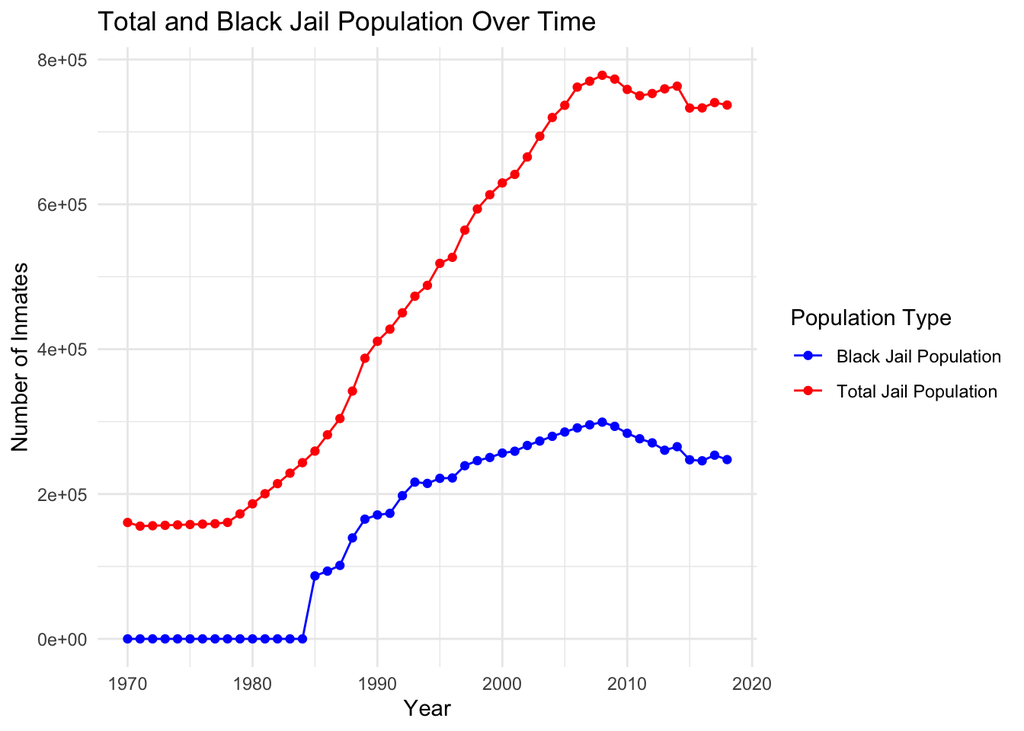

I included this chart to show the trends in the total and Black jail populations over time. By displaying these trends, we can see how the overall jail population and the population of Black inmates have changed from 1970 to 2018. The chart reveals a significant increase in both populations over the years, with a particularly steep rise during the 1980s and 1990s. This period aligns with the implementation of stricter criminal justice policies and the War on Drugs. The chart highlights the disparities between the total and Black jail populations, emphasizing the need for policy interventions to address these issues.

### Variable Comparison Chart

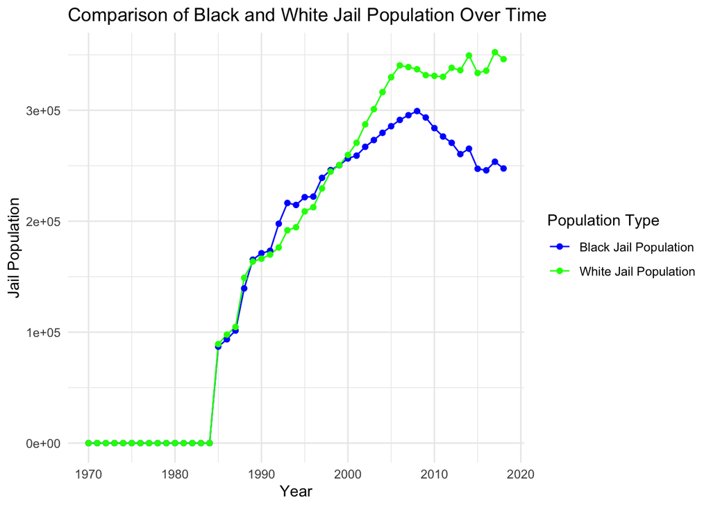

### Map

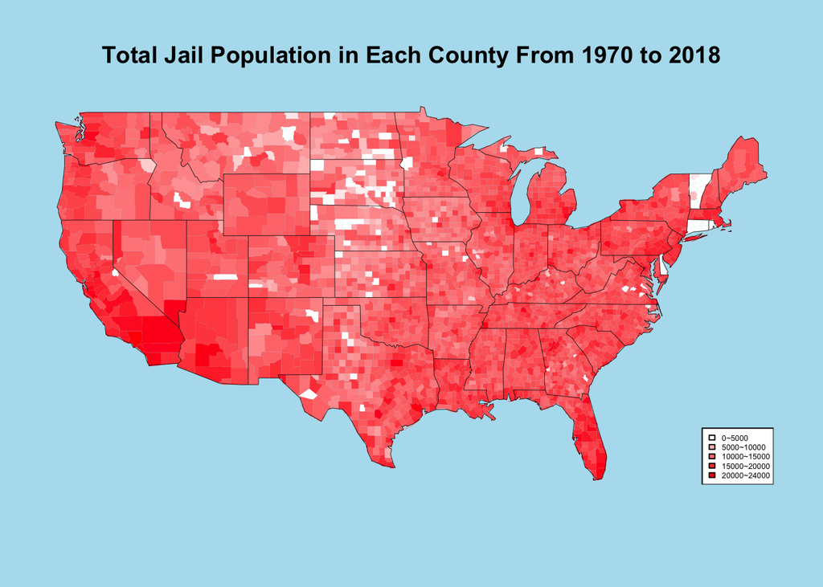

I included the map to show the geographical distribution of the jail population across different counties in the United States. The map reveals interesting patterns, such as higher incarceration rates in some areas, which might be connected to local policies, economic conditions, or high population. By seeing these geographical differences, we can start to think about why certain areas have more people in jail and what can be done to address these issues. This information is crucial for developing targeted policies and interventions to reduce high incarceration rates in specific regions and address the underlying causes.